# Covid19 Data

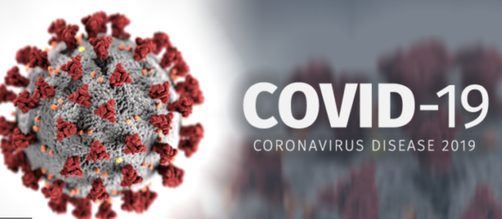

# 1 Chapter 1: Introduction

Team A are the following members: Amal Alqahtani, Jiaxiang Peng, Naureen Elahi, and Xinya Mu. You may find our work over on [GitHub](https://github.com/amalqahtani/Data_Science).

Coronavirus disease-19 (COVID-19) has spread rapidly around the world, and many risk factors have been hypothesized to affect case and death rates. We felt that a relevant discussion to have would be `What are the most regions with the highest number of deaths`? What can we say about patient demographics? Is race considered a significant risk factor for increased COVID-19 incidence in the United States?’ Are there any general trends amongst underlying health conditions? These questions are all suited to Exploratory Data Analysis (EDA), and with these questions in mind, we want to see if we could find data on COVID-19 that would be readily available for us to analyze. Eventually, our question morphed into the following: **What are the factors (i.e. patient demographics, social determinants of health, environmental variables, underlying health conditions, country of origin) affecting COVID-19 numbers of cases and death rate among different geographical locations in US?**

We were able to find a dataset called `Covid-19-Dataset` on Github over here: https://github.com/johndurbin93/Covid-19-Dataset. This dataset includes COVID-19 confirmed case number and death number through April 14, 2020 which were obtained for each U.S. county from the Center for Systems Science and Engineering (CSSE) Coronavirus Resource Center at Johns Hopkins University. Race demographics for counties was obtained from the County Health Rankings and Roadmaps Program database. Daily temperature data for counties was obtained from the National Oceanic and Atmospheric Administration. This data was compiled by a group of reserchers.

The report is organized as follows:

1. Description of the Data (explanation of the dataset and its variables),
2. Demographics Data of the patients
3. Independent Variables EDA: Slicing the Data for an Overview
4. Independent Variables EDA: Boxplots, Scatterplots, ANOVA, & Chi-Square
5. Linear Regression Model
6. Conclusion

# 2 Chapter 2: Description of the Data

## 2.1 Source Data

The data looks like the following:

```
tibble [3,144 × 82] (S3: tbl_df/tbl/data.frame)
 $ Province                                                                                               : chr [1:3144] "New York City" "Nassau" "Suffolk" "Westchester" ...
 $ State                                                                                                  : chr [1:3144] "New York" "New York" "New York" "New York" ...
 $ Latitude                                                                                               : num [1:3144] 40.8 40.7 40.9 41.2 41.8 ...
 $ Longitude                                                                                              : num [1:3144] -74 -73.6 -72.8 -73.8 -87.8 ...
 $ Tests                                                                                                  : num [1:3144] 499143 499143 499143 499143 110616 ...
 $ Days Since 1st Case                                                                                    : num [1:3144] 44 41 38 43 82 35 41 80 39 38 ...
 $ total_cases                                                                                            : num [1:3144] 110465 25250 22691 20191 16323 ...
 $ deaths                                                                                                 : num [1:3144] 7905 1001 608 596 577 ...
 $ Population (for demographic %'s)                                                                       : chr [1:3144] "8623000" "1358343" "1481093" "967612" ...
 $ % less than 18 years of age                                                                            : chr [1:3144] "20.9" "21.459675499999999" "21.134324500000002" "21.900513799999999" ...
 $ % 65 and over                                                                                          : chr [1:3144] "14.1" "17.763039200000001" "16.862951899999999" "17.053116299999999" ...
 $ % Black                                                                                                : chr [1:3144] "24.3" "11.6331442" "7.3924459799999998" "13.8042935" ...
 $ % American Indian & Alaska Native                                                                      : chr [1:3144] "0.4" "0.54294092000000005" "0.61373593999999998" "0.95647842000000005" ...
 $ % Asian                                                                                                : chr [1:3144] "13.9" "10.4504532" "4.1896086199999996" "6.43553408" ...
```

[output cut: 68 more lines]

```
# A tibble: 3,144 x 16
   Province State total_cases deaths `Population (fo… `% less than 18…
   <chr>    <chr>       <dbl>  <dbl> <chr>            <chr>
 1 New Yor… New …      110465   7905 8623000          20.9
 2 Nassau   New …       25250   1001 1358343          21.459675499999…
 3 Suffolk  New …       22691    608 1481093          21.134324500000…
 4 Westche… New …       20191    596 967612           21.900513799999…
 5 Cook     Illi…       16323    577 5180493          21.8062644
 6 Wayne    Mich…       12209    820 1753893          23.617233200000…
 7 Bergen   New …       10426    550 936692           21.176117699999…
 8 Los Ang… Cali…       10047    360 10105518         21.660374099999…
 9 Rockland New …        8335    263 325695           28.158860300000…
10 Hudson   New …        8242    277 676061           20.4450486
# … with 3,134 more rows, and 10 more variables: `% 65 and over` <chr>, `%
#   Black` <chr>, `% American Indian & Alaska Native` <chr>, `% Asian` <chr>,
#   `% Native Hawaiian/Other Pacific Islander` <chr>, `% Hispanic` <chr>, `%
#   Non-Hispanic White` <chr>, `% Not Proficient in English` <chr>, `%
#   Female` <chr>, poor_health <chr>
```

The Covid19 dataset has 82 columns and 3144 rows/entries, for a total of 257808 individual data points. Out of 82, we select the following variables to do EDA:

To prepare our data for EDA we clean the dataset and remove all NAs.

```
tibble [3,144 × 15] (S3: tbl_df/tbl/data.frame)
 $ Province                                : chr [1:3144] "New York City" "Nassau" "Suffolk" "Westchester" ...
 $ State                                   : chr [1:3144] "New York" "New York" "New York" "New York" ...
 $ total_cases                             : num [1:3144] 110465 25250 22691 20191 16323 ...
 $ deaths                                  : num [1:3144] 7905 1001 608 596 577 ...
 $ Population (for demographic %'s)        : chr [1:3144] "8623000" "1358343" "1481093" "967612" ...
 $ % less than 18 years of age             : chr [1:3144] "20.9" "21.459675499999999" "21.134324500000002" "21.900513799999999" ...
 $ % 65 and over                           : chr [1:3144] "14.1" "17.763039200000001" "16.862951899999999" "17.053116299999999" ...
 $ % Black                                 : chr [1:3144] "24.3" "11.6331442" "7.3924459799999998" "13.8042935" ...
 $ % American Indian & Alaska Native       : chr [1:3144] "0.4" "0.54294092000000005" "0.61373593999999998" "0.95647842000000005" ...
 $ % Asian                                 : chr [1:3144] "13.9" "10.4504532" "4.1896086199999996" "6.43553408" ...
 $ % Native Hawaiian/Other Pacific Islander: chr [1:3144] "0.1" "0.1" "9.5899999999999999E-2" "0.13228443000000001" ...
 $ % Hispanic                              : chr [1:3144] "29.1" "17.231362000000001" "19.775260599999999" "25.140345499999999" ...
 $ % Non-Hispanic White                    : chr [1:3144] "32.1" "59.333835399999998" "67.190378999999993" "53.088118000000001" ...
 $ % Not Proficient in English             : chr [1:3144] "9" "5.3660427200000003" "4.00639637" "6.3180527499999997" ...
 $ % Female                                : chr [1:3144] "52.3" "51.306334300000003" "50.771693599999999" "51.559095999999997" ...
```